# globant_challenge

Octavio Lafourcade

8 de agosto de 2021

## Diabetes Data Set

Esta base de datos corresponde a la información médica de pacientes relacionada a la diabetes. El análisis se centra en la readmisión anticipada (<30 días), se puede categorizar en:  
1: readmitido dentro de los 30 días posiblemente porque el tratamiento no fue el apropiado.  
0: cualquier otro caso

## Librerías a utilizar

```r
library(rmarkdown)
```

```r
library(ggplot2)
library(lattice)
library(caret)
library(stringr)
library(dplyr)
library(psych)
library(ROSE)
library(colorspace)
library(grid)
library(data.table)
library(VIM)
library(DMwR)
library(Boruta)
library(corrplot)
```

## Estableciendo el directorio de trabajo y leyendo los datos

```r
# Semilla para replicar el codigo
set.seed(1)

# Cambiar el directorio de trabajo
# setwd(dirname(rstudioapi::getActiveDocumentContext()$path))

# Leyendo el data set
data <- read.csv("./diabetic_data.csv")
attach(data)
```

## Presencia de Missing values

Se identifica la presencia de Missing values bajo los valores "?" y "Unknown/Invalid"

```r
table(weight)
```

```
## weight
##         ?    [0-25) [100-125) [125-150) [150-175) [175-200)   [25-50)   [50-75)
##     98569        48       625       145        35        11        97       897
##  [75-100)      >200
##      1336         3
```

```r
table(payer_code)
```

```
## payer_code
##     ?    BC    CH    CM    CP    DM    FR    HM    MC    MD    MP    OG    OT
## 40256  4655   146  1937  2533   549     1  6274 32439  3532    79  1033    95
##    PO    SI    SP    UN    WC
##   592    55  5007  2448   135
```

```r
table(diag_1)
```

```
## diag_1
##      ?     10     11    110    112    114    115    117    131    133    135
##     21      1     10      2     73      1      2      9      2      1     27
##    136    141    142    143    145    146    147    148    149    150    151
##      5      6      4      1      1      4      2      1      2     27     62
##    152    153    154    155    156    157    158    160    161    162    163
##     15    311     94     54     18    114     12      1     12    425      9
##    164    170    171    172    173    174    175    179    180    182    183
##      3      2     12      4      3    147      5      4      6    108     31
##    184    185    187    188    189    191    192    193    194    195    196
##     10    173      2    112    126     45      4     28      2      9     25
##    197    198    199    200    201    202    203    204    205    207    208
##    320    242     14     16     10    104     35     23     27      1      5
##    210    211    212    214    215    216    217    218    219    220    223
##      7    103      8      6      5      1      1    127      1     46      7
```

[output cut: 118 more lines]

```r
table(diag_2)
```

```
## diag_2
##      ?     11    110    111    112    114    115    117    123    130    131
##    358      3      8      1    201      1      1     10      1      1      3
##    135    136    137    138    140    141    145    150    151    152    153
##    115      6      1     22      1      2      1     35     24     13    107
##    154    155    156    157    162    163    164    171    172    173    174
##     45     33     16     85    401      1      1      2      8      1     27
##    179    180    182    183    185    186    188    189    191    192    193
##      2      1      1     14     27      1     10     48     14      1      4
##    195    196    197    198    199    200    201    202    203    204    205
##      1    213    410    320     13     19     20    182     90    117     58
##    208    211    212    214    215    217    218    220    223    225    226
##      8     54      1      8      2      3     44      8      1      5      2
##    227    228    232    233    235    238    239    240    241    242    244
##      6      2      1     12      1     17      3      2     11     94    151
```

[output cut: 124 more lines]

```r
table(diag_3)
```

```
## diag_3
##      ?     11    110    111    112    115    117    122    123    131    132
##   1423      2     20      1    206      1      7      1      1      6      3
##    135    136    138    139     14    141    146    148    150    151    152
##     64      2     21      2      1      4      1      1     13     10      3
##    153    154    155    156    157    158    161    162    163    164     17
##     55     13     12      4     38      1      3    181      5      1      1
##    170    171    172    173    174    175    179    180    182    183    185
##      4      4      5      2     43      1      7      4      5     14     51
##    186    188    189    191    192    193    195    196    197    198    199
##      1     15     27      5      2      1      1    105    385    238     45
##    200    201    202    203    204    205    208    211    214    215    216
##      9     12    122     67     66     19     10    100      3      1      2
##    217    218    220    223    225    226    227    228    230    233    235
##      1     53      5      2      7      1      6      7      1      5      4
```

[output cut: 130 more lines]

```r
table(race)
```

```
## race
##               ? AfricanAmerican           Asian       Caucasian        Hispanic
##            2273           19210             641           76099            2037
##           Other
##            1506
```

```r
table(gender)
```

```
## gender
##          Female            Male Unknown/Invalid
##           54708           47055               3
```

```r
table(medical_specialty)
```

```
## medical_specialty
##                                    ?                 AllergyandImmunology
##                                49949                                    7
##                       Anesthesiology             Anesthesiology-Pediatric
##                                   12                                   19
##                           Cardiology                 Cardiology-Pediatric
##                                 5352                                    7
##                              DCPTEAM                            Dentistry
##                                    6                                    4
##                          Dermatology                     Emergency/Trauma
##                                    1                                 7565
##                        Endocrinology             Endocrinology-Metabolism
##                                  120                                    8
##               Family/GeneralPractice                     Gastroenterology
##                                 7440                                  564
##                           Gynecology                           Hematology
##                                   58                                   82
##                  Hematology/Oncology                          Hospitalist
##                                  207                                   57
##                   InfectiousDiseases                     InternalMedicine
##                                   37                                14635
##                           Nephrology                            Neurology
##                                 1613                                  203
##                      Neurophysiology Obsterics&Gynecology-GynecologicOnco
##                                    1                                   25
##                           Obstetrics              ObstetricsandGynecology
##                                   19                                  671
##                             Oncology                        Ophthalmology
##                                  348                                   38
##                          Orthopedics           Orthopedics-Reconstructive
##                                 1400                                 1233
##                            Osteopath                       Otolaryngology
##                                   39                                  125
##                     OutreachServices                            Pathology
##                                   12                                   17
##                           Pediatrics      Pediatrics-AllergyandImmunology
##                                  254                                    3
##              Pediatrics-CriticalCare         Pediatrics-EmergencyMedicine
##                                   87                                    3
##             Pediatrics-Endocrinology       Pediatrics-Hematology-Oncology
```

[output cut: 20 more lines]

```
##                                    1                                   45
##               Surgery-Cardiovascular      Surgery-Cardiovascular/Thoracic
##                                   98                                  652
##                 Surgery-Colon&Rectal                      Surgery-General
##                                   11                                 3099
##                Surgery-Maxillofacial                        Surgery-Neuro
##                                   11                                  468
##                    Surgery-Pediatric                      Surgery-Plastic
##                                    8                                   41
##     Surgery-PlasticwithinHeadandNeck                     Surgery-Thoracic
##                                    1                                  109
##                     Surgery-Vascular                    SurgicalSpecialty
##                                  533                                   33
##                              Urology
##                                  685
```

```r
data2 <- data
```

### Pasos a seguir

1. Recodificación de Datos Perdidos
2. Diagnóstico de Datos Perdidos, MCAR o MAR?
3. Imputación de Datos Perdidos

### 1. Recodificación de Datos Perdidos

```r
data2$weight <- replace(data2$weight, data2$weight=="?", NA)
data2$payer_code <- replace(data2$payer_code, data2$payer_code=="?", NA)
data2$diag_1 <- replace(data2$diag_1, data2$diag_1=="?", NA)
data2$diag_2 <- replace(data2$diag_2, data2$diag_2=="?", NA)
data2$diag_3 <- replace(data2$diag_3, data2$diag_3=="?", NA)
data2$race <- replace(data2$race, data2$race=="?", NA)
data2$gender <- replace(data2$gender, data2$gender=="Unknown/Invalid", NA)
data2$medical_specialty <- replace(data2$medical_specialty, data2$medical_specialty=="?", NA)
```

Para ver que columnas tienen valores perdidos

```r
which(colSums(is.na(data2))!=0)
```

```
##              race            gender            weight        payer_code
##                 3                 4                 6                11
## medical_specialty            diag_1            diag_2            diag_3
##                12                19                20                21
```

Para ver el porcentaje de valores perdidos en las columnas

```r
colmiss=c(3,4,6,11,12,19,20,21)
per.miss.col=100*colSums(is.na(data2[,colmiss]))/dim(data2)[1]
per.miss.col
```

```
##              race            gender            weight        payer_code
##       2.233555411       0.002947939      96.858479256      39.557416033
## medical_specialty            diag_1            diag_2            diag_3
##      49.082208203       0.020635576       0.351787434       1.398305917
```

### 2. Diagnóstico de datos perdidos

A simple vista se puede apreciar que las variables weight, payer_code y medical_specialty tienen una considerable presencia de valores faltantes. Dado el alto porcentaje, no justificaría realizar ninguna técnica de imputación si no mas bien, retirar estas variables del análisis. En cambio, las variables race, gender, diag_1, diag_2 y diag_3 tienen una presencia de valores faltantes inferior al 5% por lo que se podría aplicar una técnica de imputación.

En este sentido, la presencia de datos perdidos se puede deber a que el instrumento de recolección no funcionaba bien y no registró cierta información. Otras alternativas es que el analista haya provocado los datos perdidos, no tenga información o es inconsistente y lo eliminó. También puede ser porque los datos no se ingresaron, el historial no se registró adecuadamente y se perdió esa información. En algunos casos va a ser necesario estimar esos valores (como en el caso de race, gender, diag_1, diag_2 y diag_3) y en otros va a ser mejor no estimarlos y dejarlos allí.

Identificando el mecanismo generador de valores perdidos  
- MCAR: valores faltantes completamente al azar  
- MAR: valores faltantes al azar como consecuencia de otros atributos  
- NMAR: valores faltantes no al azar

Usando la librería VIM

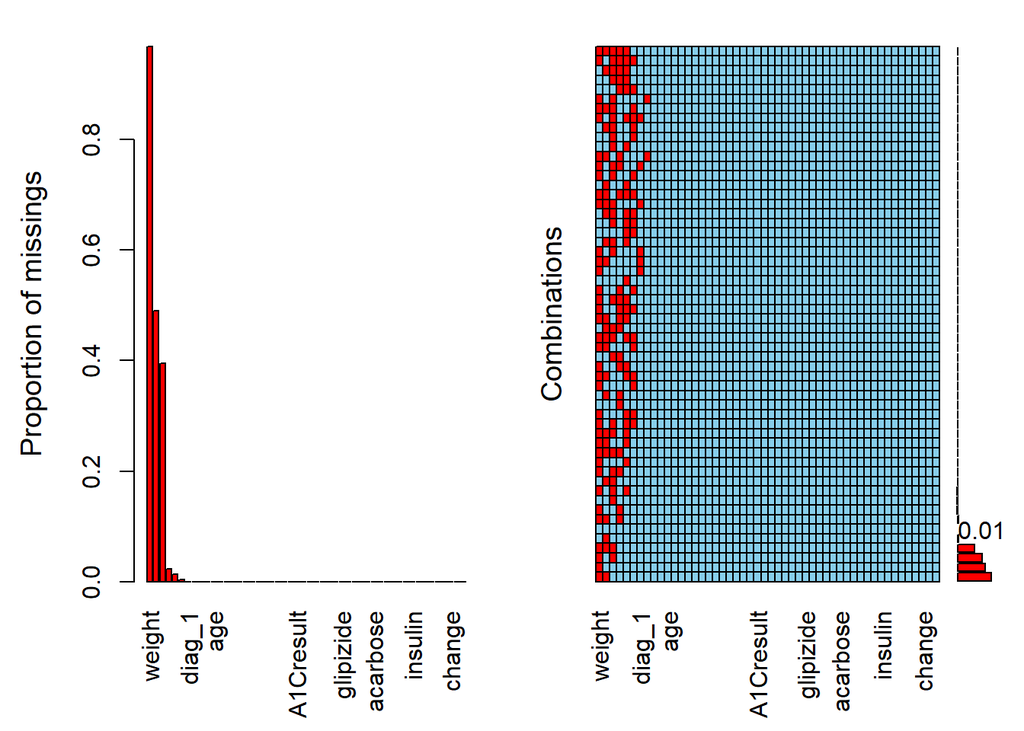

```
##
##  Variables sorted by number of missings:
##                  Variable        Count
##                    weight 9.685848e-01
##         medical_specialty 4.908221e-01
##                payer_code 3.955742e-01
##                      race 2.233555e-02
##                    diag_3 1.398306e-02
##                    diag_2 3.517874e-03
##                    diag_1 2.063558e-04
##                    gender 2.947939e-05
##              encounter_id 0.000000e+00
##               patient_nbr 0.000000e+00
##                       age 0.000000e+00
##         admission_type_id 0.000000e+00
##  discharge_disposition_id 0.000000e+00
##       admission_source_id 0.000000e+00
##          time_in_hospital 0.000000e+00
##        num_lab_procedures 0.000000e+00
##            num_procedures 0.000000e+00
##           num_medications 0.000000e+00
##         number_outpatient 0.000000e+00
##          number_emergency 0.000000e+00
##          number_inpatient 0.000000e+00
##          number_diagnoses 0.000000e+00
##             max_glu_serum 0.000000e+00
##                 A1Cresult 0.000000e+00
##                 metformin 0.000000e+00
##               repaglinide 0.000000e+00
##               nateglinide 0.000000e+00
##            chlorpropamide 0.000000e+00
##               glimepiride 0.000000e+00
##             acetohexamide 0.000000e+00
##                 glipizide 0.000000e+00
##                 glyburide 0.000000e+00
##               tolbutamide 0.000000e+00
##              pioglitazone 0.000000e+00
##             rosiglitazone 0.000000e+00
##                  acarbose 0.000000e+00
##                  miglitol 0.000000e+00
##              troglitazone 0.000000e+00
##                tolazamide 0.000000e+00
##                   examide 0.000000e+00
##               citoglipton 0.000000e+00
##                   insulin 0.000000e+00
##       glyburide.metformin 0.000000e+00
##       glipizide.metformin 0.000000e+00
##  glimepiride.pioglitazone 0.000000e+00
##   metformin.rosiglitazone 0.000000e+00
##    metformin.pioglitazone 0.000000e+00
##                    change 0.000000e+00
##               diabetesMed 0.000000e+00
##                readmitted 0.000000e+00
```

```r
#summary(a)
aggr(data2,numbers=T, sortComb=TRUE, sortVar=TRUE, only.miss=TRUE)
```

```r
#windows()
#matrixplot(data2)
```

¿MCAR, MAR o NMAR?

```r
#VIM::pbox(data2[6,11], pos=1)
#t.test(data2$weight ~ is.na(data2$payer_code), data=data2)
#marginplot(data2[,c("Weight", "Payer Code")])
```

### 3.Imputación de datos perdidos

Retirando weight, payer_code y medical_specialty

```r
data3 <- data2[,-c(6,11,12)]
```

Imputando

```r
data3<-centralImputation(data3)
data3<-initialise(data3,method="median")
```

Validando

```r
which(colSums(is.na(data3))!=0)
```

```
## named integer(0)
```

### Selección de variables dentro del contexto del negocio

1. Se ha identificado que un paciente (patient_nbr) puede tener más de un encuentro (encounter_id) y la unidad de análisis es el paciente. De este modo, se tomó la decisión de retirar la variable encounter_id
2. Se aprecia que las variables examide y citoglipton tienen solo un nivel "No" por lo que se retiran del análisis
3. Se decide trabajar con el diagnóstico principal por lo que los diagnósticos secundarios 2 y 3 son retirados

```r
data3 <- data3[,-c(1,17,18,37,38)]
```

## Feature Engineering

En esta etapa se va a realizar la recodificación de variables

### admission_type_id: Integer identifier corresponding to 9 distinct values:

1:emergency, 2:urgent, 3:elective, 4:newborn, 5:not available, 6:NULL, 7: Trauma Center, 8: Not Mapped Al analizar estas categorías se podría concluir que hay agrupaciones que se pueden realizar:  
1: emergency, urgent, Trauma Center  
3: elective  
4: newborn  
5: not available, NULL, Not Mapped

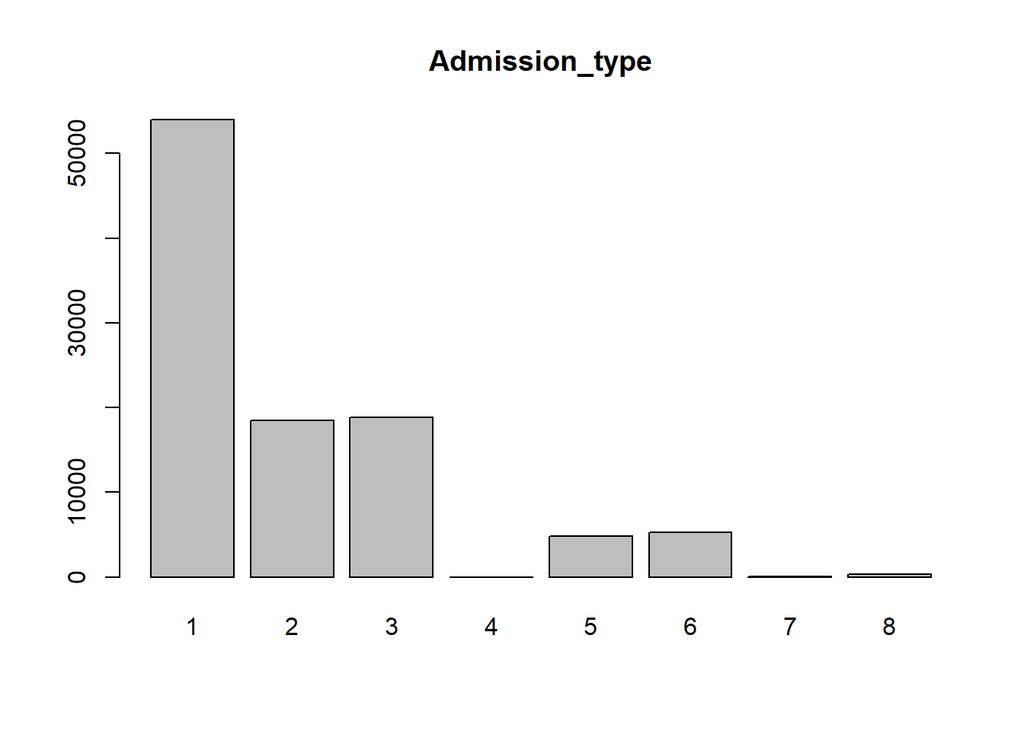

De este modo, procedemos a recategorizar:

```r
data4$admission_type_id <-
  ifelse(data3$admission_type_id == 1,1,
         ifelse(data3$admission_type_id==2,1,
                ifelse(data3$admission_type_id==7,1,
                       ifelse(data3$admission_type_id==6,5,
                              ifelse(data3$admission_type_id==8,5,
                                     data3$admission_type_id)))))
```

Cambiamos el nombre a las categorías y convertimos en factor

```r
data4$admission_type_id <- str_replace(data4$admission_type_id,"1","Emergency")
data4$admission_type_id <- str_replace(data4$admission_type_id,"5","Other")
data4$admission_type_id <- str_replace(data4$admission_type_id,"3","Elective")
data4$admission_type_id <- str_replace(data4$admission_type_id,"4","Newborn")

data4$admission_type_id <- as.factor(data4$admission_type_id)
```

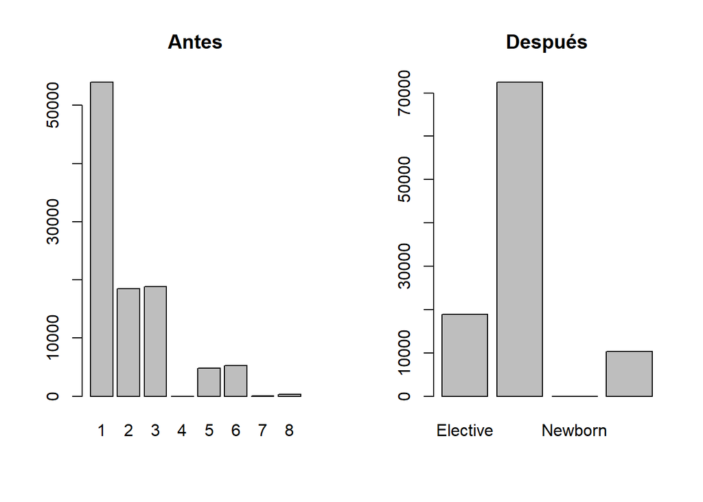

### discharge_disposition_id: Integer identifier corresponding to 29 distinct values, for example, discharged to home, expired, and not available

Categorizar en este caso se vuelve más complejo pero necesario por la atomización de categorías. Esta variable tiene las siguientes categorías:  
1: Discharged to home,  
2: Discharged/transferred to another short term hospital,  
3: Discharged/transferred to SNF, 4: Discharged/transferred to ICF,  
5: Discharged/transferred to another type of inpatient care institution,  
6: Discharged/transferred to home with home health service  
7: Left AMA  
8: Discharged/transferred to home under care of Home IV provider  
9: Admitted as an inpatient to this hospital  
10: Neonate discharged to another hospital for neonatal aftercare  
11: Expired  
12: Still patient or expected to return for outpatient services  
13: Hospice / home  
14: Hospice / medical facility  
15: Discharged/transferred within this institution to Medicare approved swing bed  
16: Discharged/transferred/referred another institution for outpatient services  
17: Discharged/transferred/referred to this institution for outpatient services  
18: NULL  
19: Expired at home. Medicaid only, hospice.  
20: Expired in a medical facility. Medicaid only, hospice.  
*21: Expired, place unknown. Medicaid only, hospice.*  
22: Discharged/transferred to another rehab fac including rehab units of a hospital  
23: Discharged/transferred to a long term care hospital.  
24: Discharged/transferred to a nursing facility certified under Medicaid but not certified under Medica...  
25: Not Mapped  
26: Unknown/Invalid <- Fue imputada  
27: Discharged/transferred to a federal health care facility.  
28: Discharged/transferred/referred to a psychiatric hospital of psychiatric distinct part unit of a hos...  
29: Discharged/transferred to a Critical Access Hospital (CAH).  
30: Discharged/transferred to another Type of Health Care Institution not Defined Elsewhere

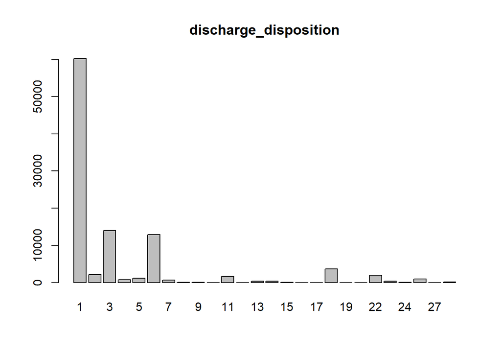

Hay tres aspectos a considerar: Por un lado, no se puede perder de vista que el objetivo es predecir si un paciente es readmitido. En este sentido, hay categorías que se relacionan con la muerte o que un paciente ha sido deshauciado y enviado a un asilo o a su casa. Tales categorías son la 11, 13, 14, 19, 20, or 21. Lo adecuado sería retirar los registros de estos pacientes del data set.

```r
data4 <- data4[ !(data4$discharge_disposition_id %in% c(11, 13, 14, 19, 20, 21)), ]
```

Se tiene la presencia de categorías con NULL y Not Mapped (18, 25) por lo que se procede a imputar

```r
data4$discharge_disposition_id <- replace(data4$discharge_disposition_id, data4$discharge_disposition_id==18, NA)
data4$discharge_disposition_id <- replace(data4$discharge_disposition_id, data4$discharge_disposition_id==25, NA)
colmiss=c(6,7)
per.miss.col=100*colSums(is.na(data4[,colmiss]))/dim(data4)[1]
per.miss.col
```

```
## discharge_disposition_id      admission_source_id
##                 4.710951                 0.000000
```

Se aprecia que las categorías 18 y 25 corresponden al 4.71% del total de registros por lo que aún se puede utilizar una técnica de imputación.

```r
data4<-centralImputation(data4)
data4<-initialise(data4,method="median")
```

Por otro lado, se aprecia una disparidad considerable entre la categoría 1 respecto al resto de categorías. Además, el resto de variables dan a entender que el paciente fue derivado a otro hospital o entidad. De este modo, se podría generar una categoría que haga referencia a Discharged/transferred ... y agrupar al resto de categorías en ella.

```r
data4$discharge_disposition_id <-
  ifelse(data4$discharge_disposition_id == 3,2,
  ifelse(data4$discharge_disposition_id==4,2,
  ifelse(data4$discharge_disposition_id==5,2,
  ifelse(data4$discharge_disposition_id==6,2,
  ifelse(data4$discharge_disposition_id==7,2,
  ifelse(data4$discharge_disposition_id==8,2,
  ifelse(data4$discharge_disposition_id==9,2,
  ifelse(data4$discharge_disposition_id==10,2,
  ifelse(data4$discharge_disposition_id==12,2,
  ifelse(data4$discharge_disposition_id==15,2,
  ifelse(data4$discharge_disposition_id==16,2,
  ifelse(data4$discharge_disposition_id==17,2,
  ifelse(data4$discharge_disposition_id==22,2,
  ifelse(data4$discharge_disposition_id==23,2,
  ifelse(data4$discharge_disposition_id==24,2,
  ifelse(data4$discharge_disposition_id==27,2,                                                                                                           ifelse(data4$discharge_disposition_id==28,2,                                                                                                           data4$discharge_disposition_id)))))))))))))))))
```

Finalmente, podemos apreciar la diferencia en la categorización

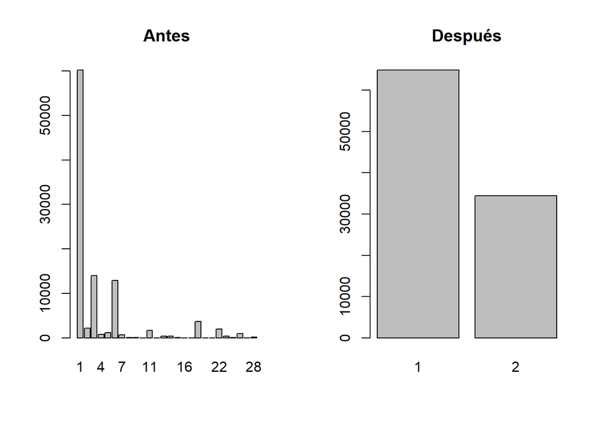

Renombramos las variables

```r
data4$discharge_disposition_id <- case_when(data4$discharge_disposition_id %in% "1" ~ "Home",TRUE ~ "Other")
```

Convirtiendo a factor

```r
data4$discharge_disposition_id <- as.factor(data4$discharge_disposition_id)
```

### admission_source_id: Integer identifier corresponding to 21 distinct values, for example, physician referral, emergency room, and transfer from a hospital

Esta variable tiene las siguientes categorías:  
1: Physician Referral  
2: Clinic Referral  
3: HMO Referral  
4: Transfer from a hospital  
5: Transfer from a Skilled Nursing Facility (SNF)  
6: Transfer from another health care facility  
7: Emergency Room  
8: Court/Law Enforcement  
9: Not Available  
10: Transfer from critial access hospital  
11: Normal Delivery  
12: Premature Delivery-  
13: Sick Baby-  
14: Extramural Birth  
15: Not Available-  
17: NULL  
18: Transfer From Another Home Health Agency-  
19: Readmission to Same Home Health Agency-  
20: Not Mapped  
21: Unknown/Invalid-  
22: Transfer from hospital inpt/same fac reslt in a sep claim  
23: Born inside this hospital-  
24: Born outside this hospital-  
25: Transfer from Ambulatory Surgery Center  
26: Transfer from Hospice-

Se puede apreciar que las categorías 1 y 7 concentran la mayor parte de los registros. Las categorías 1,2 y 3 se tratan de referidos por lo que se podrían categorizarse en una categoría. Las categorías 4,5,6,10,22,25 se tratan de transferencias desde otra entidad y podrían categorizarse en una categoría. La categoría 7 estaría individualizada. El resto de categorías podrían agruparse bajo "Otros"

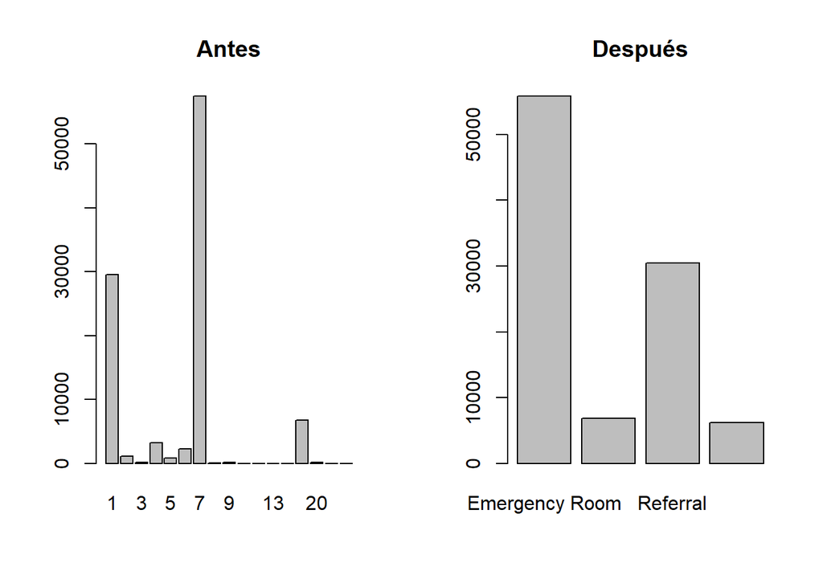

### diag_1: The primary diagnosis (coded as first three digits of ICD9); 848 distinct values

Se identificó una fuente de información que brinda una mayor noción sobre las categorías y un insight sobre la manera en la cual se podrían agrupar Las categorías que se crearían serían:  
Circulatory: Diseases of the circulatory system. Códigos: 390–459, 785  
Respiratory: Diseases of the respiratory system. Códigos: 460–519, 786  
Digestive: Diseases of the digestive system. Códigos: 520–579, 787  
Diabetes: Diabetes mellitus. Códigos: 250  
Injury: Injury and poisoning. Códigos: 800–999  
Musculoskeletal: Diseases of the musculoskeletal system and connective tissue. Códigos: 710–739  
Genitourinary: Diseases of the genitourinary system. Códigos: 580–629, 788  
Neoplasms: Neoplasms. Códigos: 140–239  
Other: around 17% of the rest are considered here.

```r
data5 <- data4
```

Se requiere convertir a caracter para abordar los registros que tienen letras

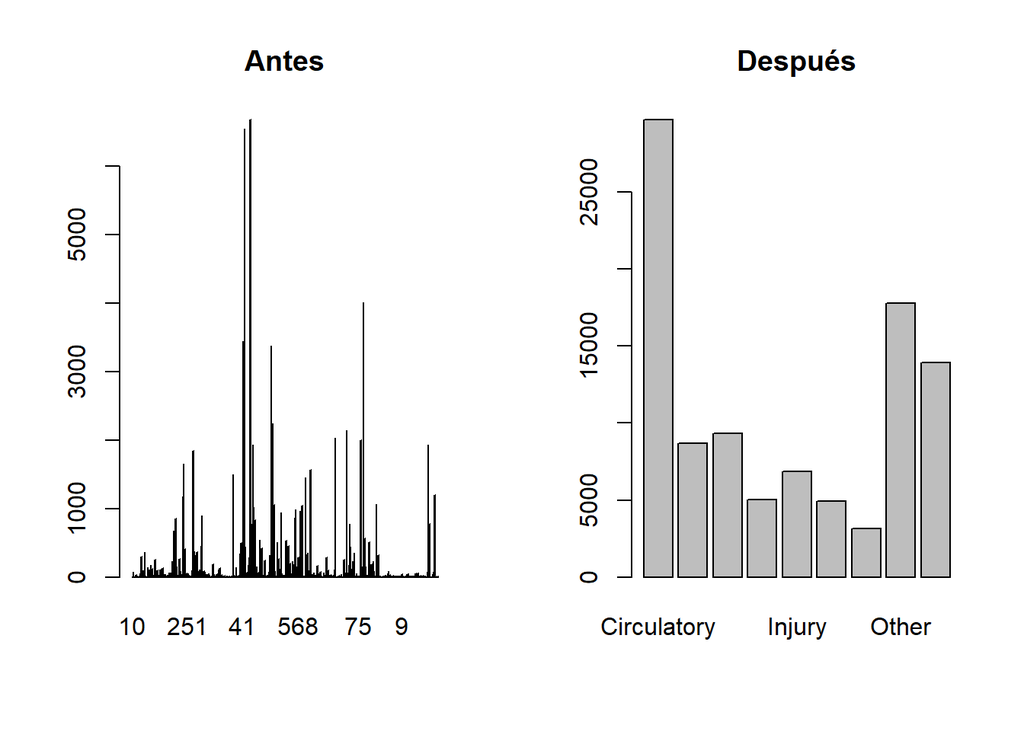

### Age: Grouped in 10-year intervals: [0, 10), [10, 20), . . ., [90, 100)

Se puede apreciar que los rangos etarios avanzan de 10 en 10. Se podría categorizar las edades de 0 a 10 y 10 a 20 en una categoría al igual que de 80 a 90 y 90 a 100 en otra y el resto de categorías tendrían un rango de 20 años también. Se aprecia también que la distribución tiene una asimetría negativa.

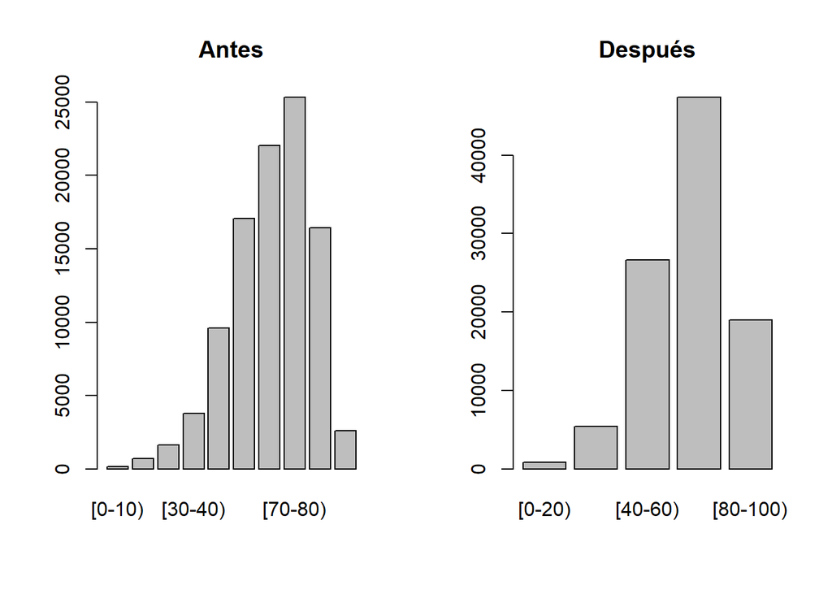

### Variables adicionales que requerirían ser retiradas del análisis

Se aprecia cierta duplicidad en cuanto a la medicación prescrita. Por ejemplo, se tiene las variables glyburide y metformin por separado pero a la vez se tiene la variable glyburide.metformin que hace referencia a la prescripción de ambos fármacos en simultáneo.

En consecuencia, se tomó la decisión de eliminar del análisis a glyburide.metformin, glipizide.metformin, glimepiride.pioglitazone, metformin.rosiglitazone y metformin.pioglitazone

```r
data5 <- subset(data5, select = -c(glyburide.metformin,
                                   glipizide.metformin,
                                   glimepiride.pioglitazone,
                                   metformin.rosiglitazone,
                                   metformin.pioglitazone))
```

### Registros duplicados que deben ser removidos

Se aprecia la presencia de duplicidad en los registros para un mismo patient_nbr en un porcentaje aproximado de 30%. Para poder remover los registros duplicados se utiliza !duplicated().

```r
data5 <- data5[!duplicated(data5$patient_nbr),]
```

### Variable TARGET readmitted: 30 days, “>30” if the patient was readmitted in more than 30 days, and “No” for no record of readmission.

El análisis se centra en la readmisión anticipada (<30 días), se puede categorizar en:  
1: readmitido dentro de los 30 días posiblemente porque el tratamiento no fue el apropiado.  
0: cualquier otro caso

```r
data5$readmitted <- case_when(data5$readmitted %in% c(">30","NO") ~ "0", TRUE ~ "1")
data5$readmitted <- as.factor(data5$readmitted)
str(data5)
```

```
## 'data.frame':    69990 obs. of  37 variables:
##  $ patient_nbr             : num  8222157 55629189 86047875 82442376 42519267 ...
##  $ race                    : Factor w/ 5 levels "AfricanAmerican",..: 3 3 1 3 3 3 3 3 3 3 ...
##  $ gender                  : Factor w/ 2 levels "Female","Male": 1 1 1 2 2 2 2 2 1 1 ...
##  $ age                     : Factor w/ 5 levels "[0-20)","[20-40)",..: 1 1 2 2 3 3 4 4 5 5 ...
##  $ admission_type_id       : Factor w/ 4 levels "Elective","Emergency",..: 4 2 2 2 2 2 1 2 2 1 ...
##  $ discharge_disposition_id: Factor w/ 2 levels "Home","Other": 1 1 1 1 1 1 1 1 1 2 ...
##  $ admission_source_id     : Factor w/ 4 levels "Emergency Room",..: 3 1 1 1 1 3 3 1 4 4 ...
##  $ time_in_hospital        : num  1 3 2 2 1 3 4 5 13 12 ...
##  $ num_lab_procedures      : num  41 59 11 44 51 31 70 73 68 33 ...
##  $ num_procedures          : num  0 0 5 1 0 6 1 0 2 3 ...
##  $ num_medications         : num  1 18 13 16 8 16 21 12 28 18 ...
##  $ number_outpatient       : num  0 0 2 0 0 0 0 0 0 0 ...
##  $ number_emergency        : num  0 0 0 0 0 0 0 0 0 0 ...
##  $ number_inpatient        : num  0 0 1 0 0 0 0 0 0 0 ...
```

[output cut: 23 more lines]

## Tratamiento de las variables numéricas (Outlier, Correlación, etc)

Revisión general

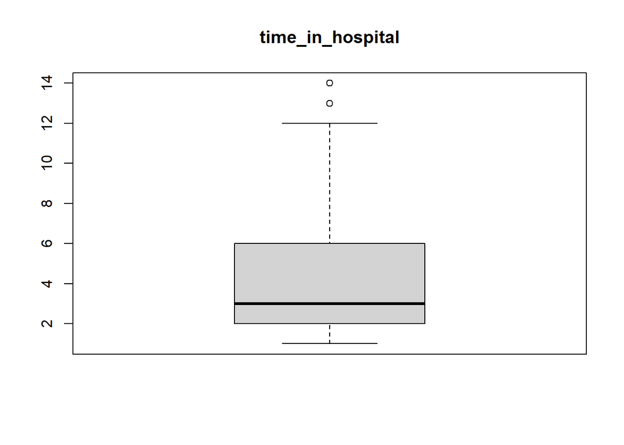

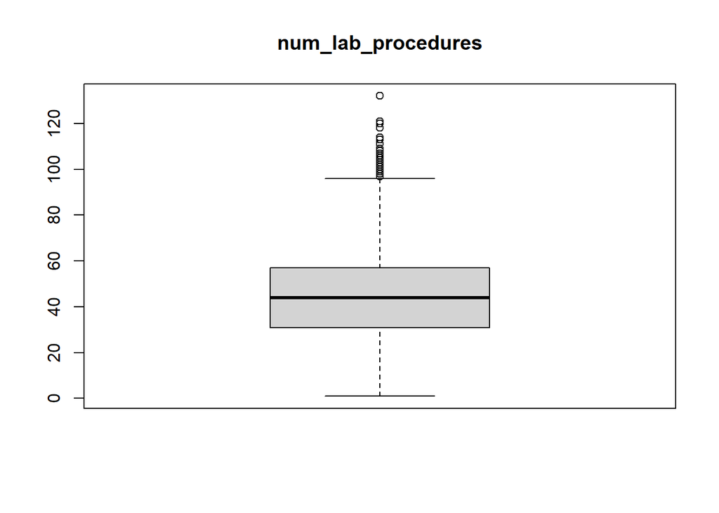

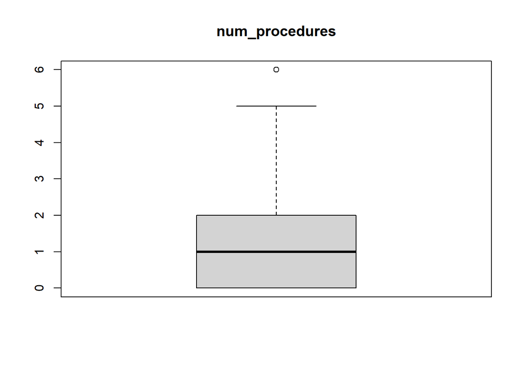

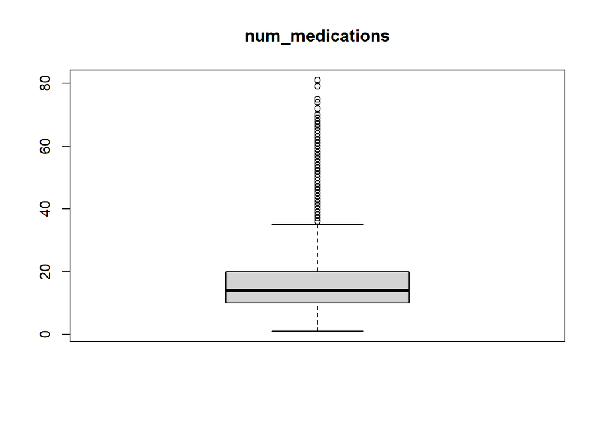

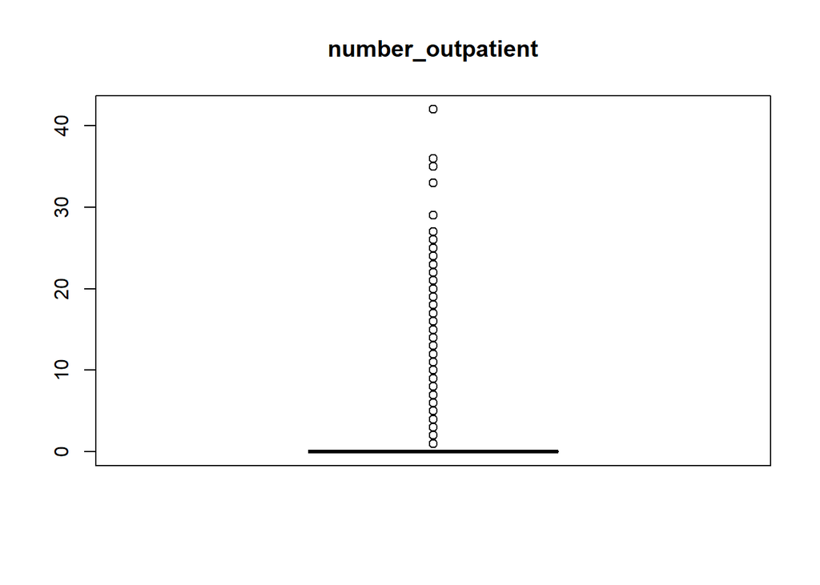

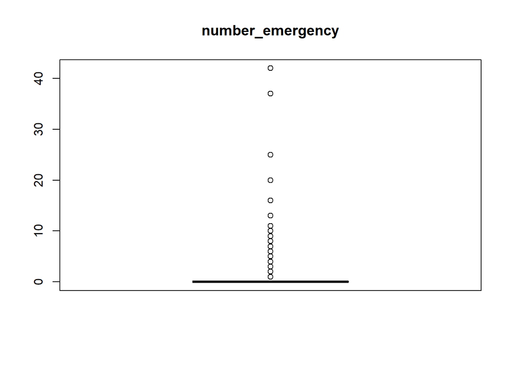

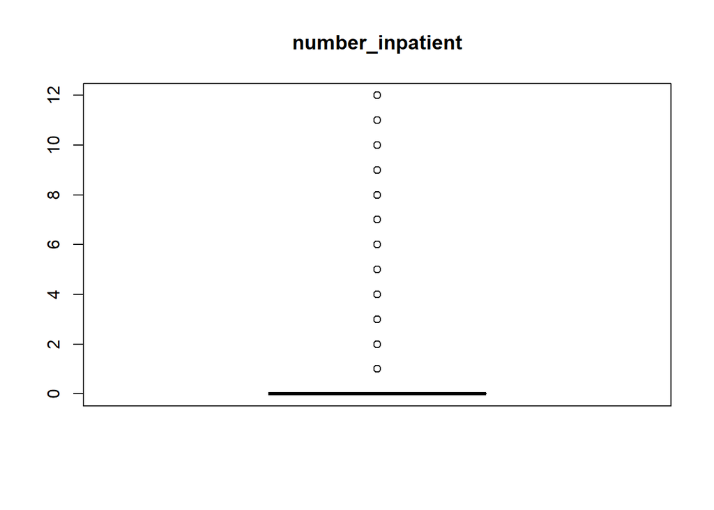

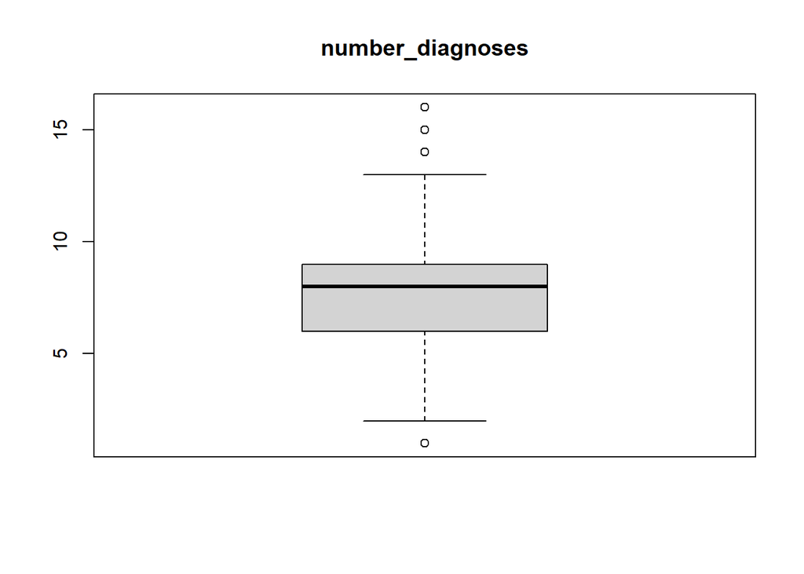

Se aprecia presencia de outliers en todas las variables numéricas analizadas ###Aplicando Capping #### time_in_hospital

```r
data6 <- data5
x <- data6$time_in_hospital
qnt <- quantile(x, probs=c(.25, .75), na.rm = T)
caps <- quantile(x, probs=c(.05, .95), na.rm = T)
H <- 1.5 * IQR(x, na.rm = T)
x[x < (qnt[1] - H)] <- caps[1]
x[x > (qnt[2] + H)] <- caps[2]
data6$time_in_hospital <- x
```

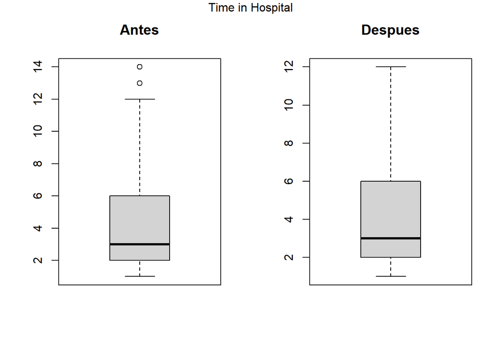

#### num_lab_procedures

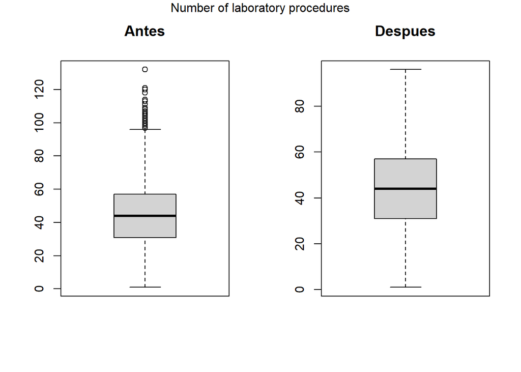

#### num_procedures

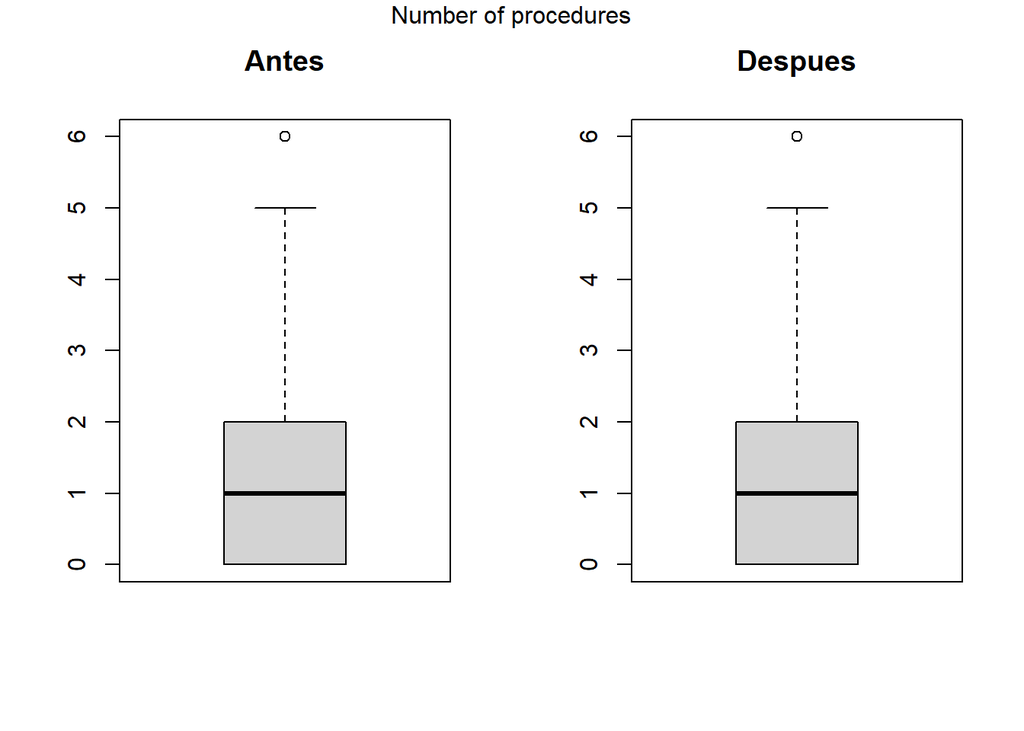

#### num_medications

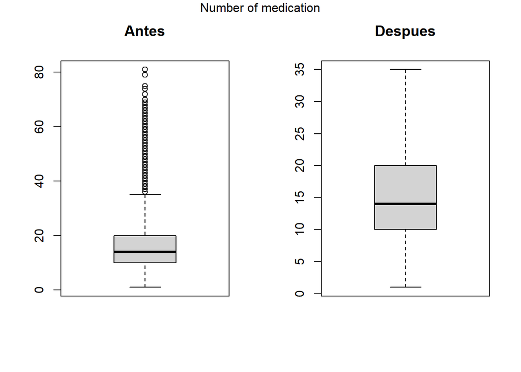

#### number_outpatient

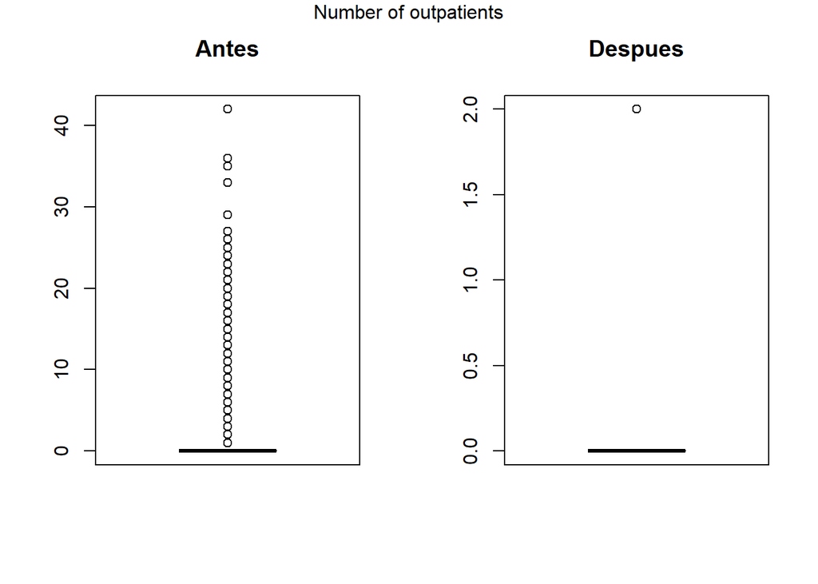

En el caso de Number of outpatients vemos que no hay mucho aporte de valor debido a la cantidad de outliers que permanecen después de aplicar capping. Se procede a optar por la eliminación de estos

```r
data6 <- subset(data6, select = -c(number_outpatient))
```

#### number_emergency

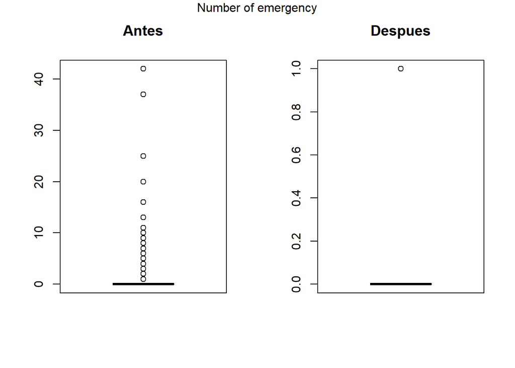

Al igual que en el caso de Number of outpatients, en Number of Emergency vemos que no hay mucho aporte de valor debido a la cantidad de outliers que permanecen después de aplicar capping. Se procede a optar por la eliminación de esta variable

```r
data6 <- subset(data6, select = -c(number_emergency))
```

#### number_inpatient

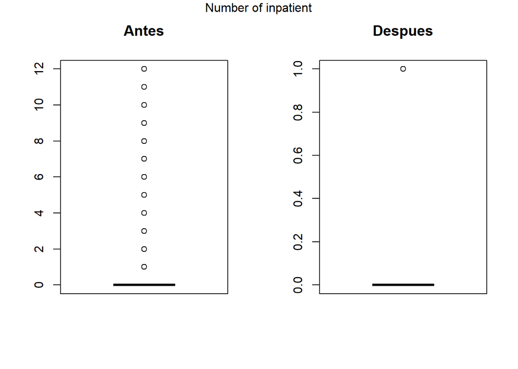

Al igual que en los dos casos previos, en Number of Inpatient vemos que no hay mucho aporte de valor debido a la cantidad de outliers que permanecen después de aplicar capping. Se procede a optar por la eliminación de esta variable

```r
data6 <- subset(data6, select = -c(number_inpatient))
```

#### number_diagnoses

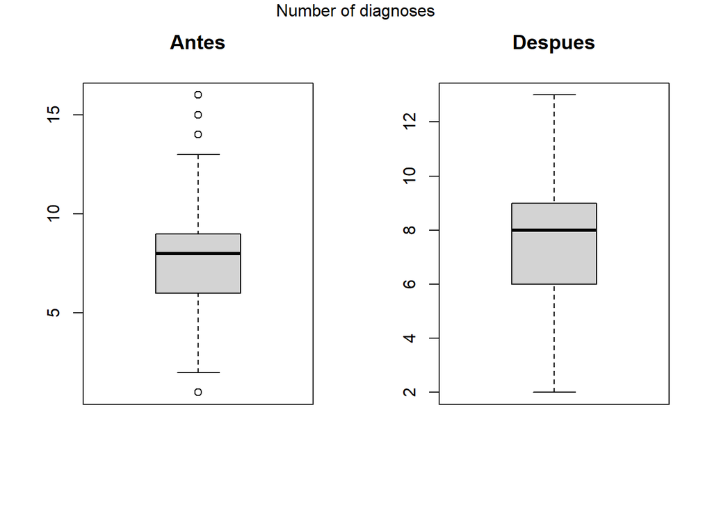

### Análisis de correlación entre variables numéricas

```r
cuantis <- data6 %>% select(time_in_hospital,
                            num_lab_procedures,
                            num_procedures,
                            num_medications,
                            number_diagnoses)

cualis <- data6%>% select(-patient_nbr,
                          -time_in_hospital,
                          -num_lab_procedures,
                          -num_procedures,
                          -num_medications,
                          -number_diagnoses)

res <- cor(cuantis)
round(res, 2)
```

```
##                    time_in_hospital num_lab_procedures num_procedures
## time_in_hospital               1.00               0.33           0.19
## num_lab_procedures             0.33               1.00           0.04
## num_procedures                 0.19               0.04           1.00
## num_medications                0.47               0.25           0.37
## number_diagnoses               0.24               0.15           0.08
##                    num_medications number_diagnoses
## time_in_hospital              0.47             0.24
## num_lab_procedures            0.25             0.15
## num_procedures                0.37             0.08
## num_medications               1.00             0.28
## number_diagnoses              0.28             1.00
```

```r
data7 <- cbind(cualis,cuantis)
```

Si bien se aprecia cierta correlación entre time_in_hospital y num_medications, esta no llega a superar el 0.6 por lo que se determina que no hay suficiente correlación entre las variables.

### Selección de variables utilizando Boruta (se basa en random forest, escoge variables con target dicotómica)

```r
#boruta <- Boruta(readmitted ~., data = data7, doTrace = 0)
#plot(boruta, las = 2, cex.axis = 1)

#attStats(boruta)
#boruta
```

Después de utilizar Boruta para la selección de variables se obtiene lo siguiente:  
18 attributes confirmed important: A1Cresult, admission_source_id, admission_type_id, age, change and 13 more; 14 attributes confirmed unimportant: acarbose, acetohexamide, chlorpropamide, glimepiride, glipizide and 9 more;

De este modo, se procederá a retirar las variables que fueron consideradas irrelevantes del dataset final

```r
dataset <-subset(data7, select = -c(acarbose,
                                    acetohexamide,
                                    chlorpropamide,
                                    glimepiride,
                                    glipizide,
                                    nateglinide,
                                    glyburide,
                                    tolbutamide,
                                    miglitol,
                                    rosiglitazone,
                                    pioglitazone,
                                    tolazamide,
                                    repaglinide,
                                    troglitazone))
```

```r
str(dataset)
```

```
## 'data.frame':    69990 obs. of  19 variables:
##  $ race                    : Factor w/ 5 levels "AfricanAmerican",..: 3 3 1 3 3 3 3 3 3 3 ...
##  $ gender                  : Factor w/ 2 levels "Female","Male": 1 1 1 2 2 2 2 2 1 1 ...
##  $ age                     : Factor w/ 5 levels "[0-20)","[20-40)",..: 1 1 2 2 3 3 4 4 5 5 ...
##  $ admission_type_id       : Factor w/ 4 levels "Elective","Emergency",..: 4 2 2 2 2 2 1 2 2 1 ...
##  $ discharge_disposition_id: Factor w/ 2 levels "Home","Other": 1 1 1 1 1 1 1 1 1 2 ...
##  $ admission_source_id     : Factor w/ 4 levels "Emergency Room",..: 3 1 1 1 1 3 3 1 4 4 ...
##  $ max_glu_serum           : Factor w/ 4 levels ">200",">300",..: 3 3 3 3 3 3 3 3 3 3 ...
##  $ A1Cresult               : Factor w/ 4 levels ">7",">8","None",..: 3 3 3 3 3 3 3 3 3 3 ...
##  $ metformin               : Factor w/ 4 levels "Down","No","Steady",..: 2 2 2 2 2 2 3 2 2 2 ...
##  $ insulin                 : Factor w/ 4 levels "Down","No","Steady",..: 2 4 2 4 3 3 3 2 3 3 ...
##  $ change                  : Factor w/ 2 levels "Ch","No": 2 1 2 1 1 2 1 2 1 1 ...
##  $ diabetesMed             : Factor w/ 2 levels "No","Yes": 1 2 2 2 2 2 2 2 2 2 ...
##  $ readmitted              : Factor w/ 2 levels "0","1": 1 1 1 1 1 1 1 1 1 1 ...
##  $ diagnostic              : chr  "Diabetes" "Other" "Other" "Other" ...
##  $ time_in_hospital        : num  1 3 2 2 1 3 4 5 11 12 ...
##  $ num_lab_procedures      : num  41 59 11 44 51 31 70 73 68 33 ...
##  $ num_procedures          : num  0 0 5 1 0 6 1 0 2 3 ...
##  $ num_medications         : num  1 18 13 16 8 16 21 12 28 18 ...
##  $ number_diagnoses        : num  4 9 6 7 5 9 7 8 8 8 ...
```

## IMPLEMENTACIÓN DE LOS MODELOS

Se decidió implementar 3 modelos: Modelo logístico, Decision Tree y Random Forest  
- Se hará un rebalanceo de los datos  
- El data set de entrenamiento tendrá el 70% de los datos  
- El data set de testing tendrá el 30% de los datos

### Seleccion de datos de entrenamiento y de testing

```r
dataset$diagnostic <- as.factor(dataset$diagnostic)
train <- createDataPartition(dataset$readmitted, p = 0.7, list = FALSE)
data_train <- dataset[train, ]
data_test <- dataset[-train, ]
str(data_train)
```

```
## 'data.frame':    48994 obs. of  19 variables:
##  $ race                    : Factor w/ 5 levels "AfricanAmerican",..: 3 3 3 3 3 3 3 1 1 3 ...
##  $ gender                  : Factor w/ 2 levels "Female","Male": 1 1 2 2 2 1 1 1 2 1 ...
##  $ age                     : Factor w/ 5 levels "[0-20)","[20-40)",..: 1 1 3 4 4 5 5 3 4 3 ...
##  $ admission_type_id       : Factor w/ 4 levels "Elective","Emergency",..: 4 2 2 1 2 2 1 2 2 2 ...
##  $ discharge_disposition_id: Factor w/ 2 levels "Home","Other": 1 1 1 1 1 1 2 1 1 2 ...
##  $ admission_source_id     : Factor w/ 4 levels "Emergency Room",..: 3 1 1 3 1 4 4 1 4 1 ...
##  $ max_glu_serum           : Factor w/ 4 levels ">200",">300",..: 3 3 3 3 3 3 3 3 3 3 ...
##  $ A1Cresult               : Factor w/ 4 levels ">7",">8","None",..: 3 3 3 3 3 3 3 3 3 3 ...
##  $ metformin               : Factor w/ 4 levels "Down","No","Steady",..: 2 2 2 3 2 2 2 2 2 3 ...
##  $ insulin                 : Factor w/ 4 levels "Down","No","Steady",..: 2 4 3 3 2 3 3 3 3 1 ...
##  $ change                  : Factor w/ 2 levels "Ch","No": 2 1 1 1 2 1 1 2 1 1 ...
##  $ diabetesMed             : Factor w/ 2 levels "No","Yes": 1 2 2 2 2 2 2 2 2 2 ...
##  $ readmitted              : Factor w/ 2 levels "0","1": 1 1 1 1 1 1 1 1 2 2 ...
##  $ diagnostic              : Factor w/ 9 levels "Circulatory",..: 2 8 7 1 1 1 1 2 7 1 ...
##  $ time_in_hospital        : num  1 3 1 4 5 11 12 9 7 7 ...
##  $ num_lab_procedures      : num  41 59 51 70 73 68 33 47 62 60 ...
##  $ num_procedures          : num  0 0 0 1 0 2 3 2 0 0 ...
##  $ num_medications         : num  1 18 8 21 12 28 18 17 11 15 ...
##  $ number_diagnoses        : num  4 9 5 7 8 8 8 9 7 8 ...
```

### Balanceo de datos

Se utiliza Random Oversampling Samples para generar datos de forma sintética

```r
data_rose <- ROSE(readmitted ~., data = data_train)$data
table(data_rose$readmitted)
```

```
##
##     0     1
## 24498 24496
```

## Implementando el modelo logistico

```r
model <- glm(readmitted ~.,family=binomial(link='logit'),data=data_rose)
logit_pred <- predict(model, newdata = data_test, interval = "confidence")
```

### Indicadores

Calcular el AUC

```r
AUC1 <- MLmetrics::AUC(logit_pred,data_test$readmitted)
```

Calcular el GINI

```r
gini1 <- 2*(AUC1) -1
```

### Calcular los valores predichos

```r
table(data_test$readmitted)
```

```
##
##     0     1
## 19111  1885
```

```r
PRED <- ifelse(logit_pred<=0.5,0,1) # pto de corte 0.5
PRED <- as.factor(PRED)
```

### Calcular la matriz de confusion

```r
tabla1 <- caret::confusionMatrix(PRED,data_test$readmitted,positive = "1")
tabla1
```

```
## Confusion Matrix and Statistics
##
##           Reference
## Prediction     0     1
##          0 17228  1555
##          1  1883   330
##
##                Accuracy : 0.8363
##                  95% CI : (0.8312, 0.8412)
##     No Information Rate : 0.9102
##     P-Value [Acc > NIR] : 1
##
##                   Kappa : 0.071
##
##  Mcnemar's Test P-Value : 2.448e-08
##
##             Sensitivity : 0.17507
##             Specificity : 0.90147
##          Pos Pred Value : 0.14912
##          Neg Pred Value : 0.91721
##              Prevalence : 0.08978
##          Detection Rate : 0.01572
##    Detection Prevalence : 0.10540
##       Balanced Accuracy : 0.53827
##
##        'Positive' Class : 1
##
```

```r
#Sensibilidad
Sensitivity1 <- MLmetrics::Sensitivity(PRED,data_test$readmitted)

#Specificity
Specificity1 <- MLmetrics::Specificity(PRED,data_test$readmitted)

#Precision
Accuracy1 <- MLmetrics::Accuracy(PRED,data_test$readmitted)

#Calcular el error de mala clasificación
error1 <- 1-Accuracy1


AUC1
```

```
## [1] 0.6161825
```

```r
gini1
```

```
## [1] 0.232365
```

```r
Accuracy1
```

```
## [1] 0.8362545
```

```r
error1
```

```
## [1] 0.1637455
```

```r
Sensitivity1
```

```
## [1] 0.9172124
```

```r
Specificity1
```

```
## [1] 0.1491188
```

## Implementando el modelo Decision Tree

```r
library(rpart)
DTModel <- train(readmitted ~ ., data = data_rose, method = "rpart")
#DTModel <- rpart(readmitted ~ ., data = data_rose)
DT_pred <- predict(DTModel, newdata = data_test)
```

# Indicadores

Calculando el AUC

```r
AUC2 <- MLmetrics::AUC(DT_pred,data_test$readmitted)
```

calcular el GINI

```r
gini2 <- 2*(AUC2) -1
```

### Calcular los valores predichos

```r
table(data_test$readmitted)
```

```
##
##     0     1
## 19111  1885
```

```r
PRED2 <- ifelse(as.numeric(as.character(DT_pred))<=0.5,0,1) # pto de corte 0.5
PRED2 <- as.factor(PRED2)
table(PRED2)
```

```
## PRED2
##     0     1
## 11000  9996
```

### Calcular la matriz de confusion

```r
tabla2 <- caret::confusionMatrix(PRED2,data_test$readmitted,positive = "1")
tabla2
```

```
## Confusion Matrix and Statistics
##
##           Reference
## Prediction     0     1
##          0 10290   710
##          1  8821  1175
##
##                Accuracy : 0.5461
##                  95% CI : (0.5393, 0.5528)
##     No Information Rate : 0.9102
##     P-Value [Acc > NIR] : 1
##
##                   Kappa : 0.055
##
##  Mcnemar's Test P-Value : <2e-16
##
##             Sensitivity : 0.62334
##             Specificity : 0.53843
##          Pos Pred Value : 0.11755
##          Neg Pred Value : 0.93545
##              Prevalence : 0.08978
##          Detection Rate : 0.05596
##    Detection Prevalence : 0.47609
##       Balanced Accuracy : 0.58089
##
##        'Positive' Class : 1
##
```

```r
# Sensibilidad
Sensitivity2 <- MLmetrics::Sensitivity(PRED2,data_test$readmitted)

# Specificity
Specificity2 <- MLmetrics::Specificity(PRED2,data_test$readmitted)

# Precision
Accuracy2 <- MLmetrics::Accuracy(PRED2,data_test$readmitted)

# Calcular el error de mala clasificación
error2 <- 1-Accuracy2

# indicadores
AUC2
```

```
## [1] 0.5808878
```

```r
gini2
```

```
## [1] 0.1617755
```

```r
Accuracy2
```

```
## [1] 0.5460564
```

```r
error2
```

```
## [1] 0.4539436
```

```r
Sensitivity2
```

```
## [1] 0.9354545
```

```r
Specificity2
```

```
## [1] 0.117547
```

### Implementando el modelo Random Forest

OJO: Se tuvo que detener el entrenamiento después de alrededor de 4 horas debido a que no terminaba

```r
#RFModel <- train(readmitted ~ ., data = data_rose, method = "rf")

#RF_pred <- predict(RFModel, newdata = data_test, interval = "confidence")
```

# Indicadores

Calculando el AUC

```r
#AUC3 <- MLmetrics::AUC(RF_pred,data_test$readmitted)
```

calcular el GINI

```r
#gini3 <- 2*(AUC2) -1
```

Calcular el KS

```r
#KS3 <- MLmetrics::KS_Stat(RF_pred,data_test$readmitted)
```

### Calcular los valores predichos

```r
#PRED <- ifelse(RF_pred<=0.5,0,1) # pto de corte 0.5
#PRED <- as.factor(PRED)
```

### Calcular la matriz de confusion

```r
#tabla3 <- caret::confusionMatrix(PRED,data_test$readmitted,positive = "1")
#tabla3
```

```r
# Sensibilidad
#Sensitivity3 <- MLmetrics::Sensitivity(PRED,data_test$readmitted)

# Specificity
#Specificity3 <- MLmetrics::Specificity(PRED,data_test$readmitted)

# Precision
#Accuracy3 <- MLmetrics::Accuracy(PRED,data_test$readmitted)

# Calcular el error de mala clasificación
#error3 <- 1-Accuracy3

#indicadores
#AUC3
#gini3
#LogLoss3
#KS3
#Accuracy3
#error3
#Sensitivity3
#Specificity3
```

### Resultados finales

```r
AUC <- rbind(AUC1,AUC2); AUC <- round(AUC,3)
Accuracy <- rbind(Accuracy1,Accuracy2); Accuracy <- round(Accuracy,3)
Sensitivity <- rbind(Sensitivity1,Sensitivity2); Sensitivity <- round(Sensitivity,3)
Indicadores <- cbind(AUC,Accuracy,Sensitivity)
rownames(Indicadores)<- c('modelo_logit','modelo_DecisionTree')
colnames(Indicadores)<- c('AUC','Accuracy','Sensitivity')

Indicadores
```

```
##                       AUC Accuracy Sensitivity
## modelo_logit        0.616    0.836       0.917
## modelo_DecisionTree 0.581    0.546       0.935
```

## Conclusiones

En base al análisis realizado con un modelo logistico y el modelo decision tree, se concluye que el modelo logistico es el mejor modelo para clasificar la variable readmission.